# 第五章： 专题 1： 点数据分析

**模块 6：逐项比较并校正。**对“两区 × 两类设施”分别计算，四项检验统一作 Holm 校正；图上注释与结果表复用同一结果。

```r
# group_modify() 将每个“区 × 设施”的记录交给函数；四项检验一起校正。
transit_tests <- distance_long %>%
  group_by(district_name, slug, station_type) %>%
  group_modify(~ compare_aoi_distance(.x)) %>%
  ungroup() %>%
  mutate(
    # p.adjust() 将四项原始 p 值一起作 Holm 校正。
    p_holm = p.adjust(p_raw, method = "holm"),
    # case_when() 从最小 p 值开始匹配，每项只保留一种星号。
    significance = case_when(
      p_holm < .001 ~ "***", p_holm < .01 ~ "**",
      p_holm < .05 ~ "*", TRUE ~ "ns"
    ),
    p_label = if_else(
      p_holm < .001, "Holm P < 0.001",
      paste0("Holm P = ", formatC(p_holm, format = "f", digits = 3))
    )
  ) %>%
  arrange(slug, station_type)

# 图中的均值差、区间和星号由计算结果生成，输入改变时会同步更新。
transit_annotations <- transit_tests
```

**模块 7：设置浅深色主题。**`figure_theme` 选择配色，文字、图层与注释同时跟随主题。

```r
figure_theme <- "light"  # 改为"dark"可切换深色主题
transit_palettes <- list(
  light = list(
    page = "#FFFFFF", ink = "#29353A", muted = "#4A555D", grid = "#E7ECEE",
    frame = "#7A8A91", cloud_line = "#51646E", aoi = "#5B91A6",
    non_aoi = "#C58B70", box_fill = "#FFFFFF", box_line = "#29353A",
    mean = "#B9535F", star = "#A13C4C"
  ),
  dark = list(
    page = "#211F25", ink = "#F1EDF1", muted = "#CAC3CD", grid = "#423E48",
    frame = "#9B919F", cloud_line = "#B6BDC7", aoi = "#87BACF",
    non_aoi = "#E3AA8D", box_fill = "#F1EDF1", box_line = "#29353A",
    mean = "#F299A0", star = "#F299A0"
  )
)
palette <- transit_palettes[[figure_theme]]
```

**模块 8：定义云雨图面板。**依次绘制半小提琴、雨点、箱线与均值菱形，并标注均值差、区间和检验星号。

```r
make_transit_panel <- function(slug_value, station_value) {
  # 每个面板只保留当前区、当前设施对应的数据与检验注释。
  box_data <- filter(
    box_summary, slug == slug_value, station_type == station_value
  )
  cloud_data <- filter(
    density_polygons, slug == slug_value, station_type == station_value
  )
  dot_data <- filter(
    dot_cells, slug == slug_value, station_type == station_value
  )
  test_data <- filter(
    transit_annotations, slug == slug_value, station_type == station_value
  )

  maximum_view <- max(cloud_data$distance_view)
  bracket_x <- maximum_view * 1.035
  effect_label <- sprintf(
    "Mean difference (Non-AOI − AOI)  %+.1f m",
    test_data$estimate_out_minus_in_m
  )
  inference_label <- paste0(
    "95% CI [", sprintf("%.1f", test_data$ci_low_m), ", ",
    sprintf("%.1f", test_data$ci_high_m), "] m · ", test_data$p_label
  )

  # 横轴刻度仍以米标注，只保留当前面板显示范围内的刻度。
  break_m <- c(0, 50, 100, 250, 500, 1000, 2000, 5000, 10000, 20000)
  break_m <- break_m[
    distance_transform$transform(break_m) <= maximum_view * 1.02
  ]

  ggplot() +
    # 云：全量距离的平滑密度轮廓。
    geom_polygon(
      data = cloud_data,
      aes(distance_view, density_y, group = aoi_status, fill = aoi_status),
      alpha = .56, colour = palette$cloud_line, linewidth = .28
    ) +
    # 雨：固定显示子样本，alpha直接使用每个点代表的记录数。
    geom_point(
      data = dot_data, aes(dot_x, dot_y, fill = aoi_status, alpha = dot_alpha),
      shape = 21, size = 1.08, stroke = .08, colour = palette$page
    ) +
    # 箱线胡须与端帽分别用线段绘制，位置来自原米制统计量的显示坐标。
    geom_segment(
      data = box_data,
      aes(x = whisker_low_m_view, xend = whisker_high_m_view,
          y = group_id, yend = group_id),
      linewidth = .45, colour = palette$ink
    ) +
    geom_segment(
      data = box_data,
      aes(x = whisker_low_m_view, xend = whisker_low_m_view,
          y = group_id - whisker_half_height,
          yend = group_id + whisker_half_height),
      linewidth = .45, colour = palette$ink
    ) +
    geom_segment(
      data = box_data,
      aes(x = whisker_high_m_view, xend = whisker_high_m_view,
          y = group_id - whisker_half_height,
          yend = group_id + whisker_half_height),
      linewidth = .45, colour = palette$ink
    ) +
    geom_rect(
      data = box_data,
      aes(xmin = q25_m_view, xmax = q75_m_view,
          ymin = group_id - box_half_height, ymax = group_id + box_half_height),
      fill = palette$box_fill, colour = palette$box_line, linewidth = .45
    ) +
    geom_segment(
      data = box_data,
      aes(x = median_m_view, xend = median_m_view,
          y = group_id - box_half_height, yend = group_id + box_half_height),
      colour = palette$box_line, linewidth = .65
    ) +
    # 菱形表示原始米数均值，与箱体中线的中位数区分。
    geom_point(
      data = box_data, aes(mean_m_view, group_id), shape = 23, size = 3,
      fill = palette$mean, colour = palette$page, stroke = .45
    ) +
    geom_text(
      data = box_data,
      aes(x = 0, y = group_id + count_label_offset, label = count_label),
      family = "Arial", hjust = 0, size = 4, colour = palette$muted
    ) +
    # 三条线段组成组间括号，星号对应均值差检验而非中位数比较。
    annotate(
      "segment", x = bracket_x, xend = bracket_x, y = 1, yend = 2,
      linewidth = .5, colour = palette$muted
    ) +
    annotate(
      "segment", x = bracket_x - .025 * maximum_view, xend = bracket_x,
      y = 1, yend = 1, linewidth = .5, colour = palette$muted
    ) +
    annotate(
      "segment", x = bracket_x - .025 * maximum_view, xend = bracket_x,
      y = 2, yend = 2, linewidth = .5, colour = palette$muted
    ) +
    annotate(
      "text", x = bracket_x + .025 * maximum_view, y = 1.5,
      label = test_data$significance, family = "Arial", size = 5.2,
      fontface = "bold", colour = palette$star, hjust = 0
    ) +
    scale_fill_manual(
      values = c(AOI = palette$aoi, nonAOI = palette$non_aoi), guide = "none"
    ) +
    scale_alpha_identity() +
    scale_x_continuous(
      breaks = distance_transform$transform(break_m),
      labels = scales::label_number(big.mark = ",")(break_m),
      limits = c(0, maximum_view * 1.16), expand = expansion(mult = c(0, 0))
    ) +
    scale_y_continuous(
      breaks = c(1, 2), labels = c("Non-AOI", "AOI"),
      limits = panel_y_limits, expand = expansion(mult = c(0, 0))
    ) +
    labs(
      title = facility_labels[[station_value]],
      subtitle = paste(effect_label, inference_label, sep = "\n"),
      x = "Nearest-POI straight-line distance (m; pseudo-log scale)", y = NULL
    ) +
    theme_classic(base_family = "Arial", base_size = 16) +
    theme(
      text = element_text(colour = palette$ink),
      plot.title = element_text(
        colour = palette$ink, size = 20, face = "bold", margin = margin(b = 12)
      ),
      plot.subtitle = element_text(
        colour = palette$muted, size = 13.5, lineheight = 1.35,
        margin = margin(b = 15)
      ),
      axis.text = element_text(colour = palette$muted, size = 13),
      axis.text.y = element_text(colour = palette$ink, size = 16, face = "bold"),
      axis.title.x = element_text(
        colour = palette$ink, size = 13, margin = margin(t = 10)
      ),
      axis.line.y = element_blank(), axis.ticks.y = element_blank(),
      axis.line.x = element_line(colour = palette$frame, linewidth = .35),
      axis.ticks.x = element_line(colour = palette$frame, linewidth = .35),
      axis.ticks.length = grid::unit(3, "pt"),
      panel.grid.major.x = element_line(colour = palette$grid, linewidth = .28),
      plot.background = element_rect(fill = "transparent", colour = NA),
      panel.background = element_rect(fill = "transparent", colour = NA),
      plot.margin = margin(10, 28, 12, 12)
    )
}
```

**模块 9：组合并显示。**每区将公交与地铁两个面板并排排列；直接输出对象即可显示，无需保存图片。

```r
make_district_raincloud <- function(slug) {
  # 对bus与subway分别调用面板函数，再用patchwork按两列组合。
  panels <- lapply(
    names(facility_labels),
    function(station_type) make_transit_panel(slug, station_type)
  )
  wrap_plots(panels, ncol = 2) +
    plot_annotation(
      theme = theme(
        plot.background = element_rect(fill = "transparent", colour = NA)
      )
    )
}

transit_minhang <- make_district_raincloud("minhang")
transit_putuo <- make_district_raincloud("putuo")

# 分别运行对象名，即可在RStudio的Plots面板查看两张组合图。
transit_minhang
transit_putuo
```

[output not shown]

**知识卡 · p 值、星号与差异大小**

本节检验 AOI 内外的**平均距离是否相同**。假定两组总体均值相同且模型假设成立，原始 *p* 值是得到当前或更极端检验统计量的概率。

同一账号的记录可能相关，因此标准误**按账号聚类**；两区、两类设施的 **4 项比较统一作 Holm 校正**。星号对应校正后的 *p* 值：

*p* < 0.001

0.001 ≤ *p* < 0.01

0.01 ≤ *p* < 0.05

**ns**

*p* ≥ 0.05

*p* 值不表示原假设为真的概率，也不衡量差异大小；ns 表示未达阈值，不能证明两组相同。还需查看**均值差（米）与置信区间**；图中区间为逐项 95% 区间。

**均值差与统计比较**

均值差定义为**非AOI减AOI**。正值表示AOI内记录的平均距离较短，负值表示非AOI记录的平均距离较短。

非AOI减AOI的记录加权均值差与账号聚类稳健检验

| 研究区 | 设施 | AOI内均值（m） | 非AOI均值（m） | 均值差（m） | 逐项95%区间（m） | Holm p值 |
| --- | --- | --- | --- | --- | --- | --- |
| 闵行区 | 公交类POI | 191.0 | 206.9 | 15.9 | [9.2, 22.7] | < 0.001 |
| 闵行区 | 地铁类POI | 495.1 | 942.6 | 447.4 | [425.6, 469.3] | < 0.001 |
| 普陀区 | 公交类POI | 211.2 | 163.1 | -48.0 | [-53.5, -42.5] | < 0.001 |
| 普陀区 | 地铁类POI | 344.8 | 451.9 | 107.1 | [91.6, 122.6] | < 0.001 |

**表格代码 · 均值差与检验结果复用同一统计结果，显示时再舍入**

先运行上方完整代码中的距离与账号聚类检验模块，再将 `transit_tests` 整理为结果表。

```r
# 复用上一步的检验结果；数值仅在显示时舍入，检验保留原精度。
transit_tests %>%
  transmute(
    研究区 = district_name,
    设施 = if_else(station_type == "bus", "公交类 POI", "地铁类 POI"),
    `AOI 内均值（m）` = round(mean_inside_m, 1),
    `非 AOI 均值（m）` = round(mean_outside_m, 1),
    `均值差（m）` = round(estimate_out_minus_in_m, 1),
    `逐项 95% 区间（m）` = sprintf("[%.1f, %.1f]", ci_low_m, ci_high_m),
    `Holm p 值` = if_else(
      p_holm < .001, "< 0.001", formatC(p_holm, format = "f", digits = 3)
    )
  ) %>%
  knitr::kable(row.names = FALSE, caption = "非 AOI 减 AOI 的均值差与账号聚类稳健检验")
```

**闵行：地铁距离的组间差异更突出**

- **地铁类POI：** AOI内平均距离短447.4米，中位数短273.0米。
- **公交类POI：** AOI内平均距离短15.9米，中位数短33.9米。地铁与公交的差异幅度不在同一量级。

**普陀：两类设施呈现不同方向**

- **地铁类POI：** AOI内平均距离短107.1米，中位数短110.6米。
- **公交类POI：** AOI内平均距离长48.0米，中位数长70.7米。同一AOI对两种交通方式呈现不同的邻近关系。

四项均值差的95%区间均未跨过0，Holm校正后均为**p < 0.001**；中位数差的方向与均值差一致，幅度则不同。闵行非AOI的地铁距离右尾更长，最大值约5.23千米，AOI内约1.53千米。最大值用于识别长尾，不代表整组记录的典型水平；星号也只对应均值差检验。

**从现象到讨论：四条可以继续核查的思路**

1. **地铁差异可能与活动空间的轨道导向有关。** 两区AOI内的地铁距离都较短，说明高密度记录与地铁POI在空间上较为接近。一种可检验的解释是，商业、办公或公共活动场所沿轨道走廊集聚，社交媒体记录随之集中。后续可叠加地铁线路、站点出入口与土地利用，检查AOI是否确实沿轨道走廊或特定功能区展开。
2. **区际差值需要从空间构成中寻找原因。** 闵行的地铁均值差为447.4米，普陀为107.1米。AOI的位置、非AOI记录覆盖的空间范围、行政区尺度和地铁网络布局，都可能影响这一差距。两区AOI面积与记录覆盖比例不同，不宜据此排列两区交通便利程度；可分别绘制AOI内外记录与轨道设施，并比较其空间区位。
3. **公交与地铁的差异提示交通方式需要分别讨论。** 普陀AOI更靠近地铁类POI，却离公交类POI更远。这可能与公交线路、道路网络和活动场所的相对位置有关，也可能受到POI分类与站点粒度的影响。将公交站、线路和路网加入分析，才能判断它反映的是设施布局、换乘关系，还是数据记录方式。
4. **空间公平关注需求与供给是否匹配。** 非AOI记录距离地铁更远，可以引出“线上活动较少的空间是否也面临较弱的轨道邻近性”这一问题。如果这些位置同时具有较高居住或通勤需求、较少线路选择和较长步行时间，才可能构成服务短缺的进一步证据。社交媒体非AOI不等同于居民区或需求群体，公平评价还需结合人口、出行目的及不同人群的实际出行成本。

**从空间邻近到实际便利，还需要哪些信息？**

- **步行可达：** 直线距离未计入站点入口、路网阻隔、过街条件与步行路径。
- **服务质量：** 线路方向、班次、换乘、运营时段与无障碍条件都会影响距离相近时的实际便利。
- **解释边界：** 交通POI的采集年份、运营状态和站体或入口粒度尚未确认；检验以当前AOI固定为条件，跨账号空间相关与AOI识别不确定性未纳入，结果作为探索性条件比较阅读。

**延伸阅读 · 多组比较怎样选方法总体比较、两两比较与重复观测**

例如比较 A、B、C 三组成绩：**总体检验**判断是否存在组间差异，**两两比较**判断哪些组不同。三组共有 3 对，需要处理多重比较。

| 数据与比较目标 | 可采用的方法 |
| --- | --- |
| 独立组，比较均值，方差可不同 | [Welch ANOVA](https://stat.ethz.ch/R-manual/R-devel/library/stats/html/oneway.test.html)；两两比较用 [Games–Howell](https://rpkgs.datanovia.com/rstatix/reference/games_howell_test.html) |
| 独立组，比较均值，等方差假设合理 | 单因素 ANOVA；两两比较用 [Tukey HSD](https://stat.ethz.ch/R-manual/R-devel/library/stats/html/TukeyHSD.html) |
| 独立组，比较秩或分布位置 | Kruskal–Wallis；两两比较用 [Dunn＋Holm](https://rpkgs.datanovia.com/rstatix/reference/dunn_test.html)（第 3 章示例） |
| 同一对象重复观测，或记录按账号聚类 | 重复测量或混合模型；也可按设计采用聚类稳健比较 |

先明确比较目标和观测之间的关系，再选择方法。秩检验不能直接当作中位数检验；Games–Howell 与 Tukey 已处理其两两比较的多重性。

**推荐阅读**

- [ASA（2016）p 值声明](https://www.amstat.org/asa/files/pdfs/P-ValueStatement.pdf)：理解 p 值、差异大小与研究判断的关系。
- [R · p.adjust()](https://stat.ethz.ch/R-manual/R-devel/library/stats/html/p.adjust.html)：查看 Holm 等多重比较校正方法。
- 第 3 章 3.6 · 进阶云雨图：回看 Kruskal–Wallis、Dunn 与 Holm 的完整示例。

**© 华东师范大学 社会发展学院 人口研究所** | [**DAWN 研究组**](https://dawn-ecnu.github.io) | yzliu@soci.ecnu.edu.cn

课程负责人：刘贇喆 本章作者：刘贇喆 | 敖漪宇

最后更新：2026年11月13日 构建环境：R version 4.6.1 (2026-06-24 ucrt)

[CC BY-NC-SA 4.0](https://creativecommons.org/licenses/by-nc-sa/4.0/deed.zh) 回到顶部

## **5.0 专题研究 2：回顾与反思**

### **5.0 专题研究 2：回顾与反思**

**5.1 从本例结果出发**

以社交媒体记录识别**城市兴趣区**，比较 **AOI 内外的公共交通设施可达性**。

1. 数据

   **72,000** 条**微博与小红书**地理标记记录，覆盖 2023—2025 年。
2. 识别

   **闵行区 · 普陀区**，分别开展核密度估计（KDE）。提取区内密度达到第 95 百分位（P95）的区域，定义为**城市兴趣区（AOI）**。
3. 比较

   以最近公交、地铁 POI 的**直线距离**，比较 **AOI 内与非 AOI** 的公共交通设施可达性。

空间形态

闵行：**4 斑块 · 18.63 km² · 记录覆盖 35.43%**普陀：**3 斑块 · 2.77 km² · 记录覆盖 28.47%**

地铁邻近

AOI 内平均距离：闵行短 **447.4 米**，普陀短 **107.1 米**。

公交对照

AOI 内平均距离：闵行短 **15.9 米**，普陀长 **48.0 米**。

两区的**地铁距离差方向一致**，公交距离差方向不同，需结合设施类型解释。

区域内随机抽样与结果稳定性

本例在每个“区 × 平台 × 年份”中随机抽取 **6,000 条**。抽样波动可能影响 KDE 峰值、AOI 边界与距离差。

真实研究宜优先使用研究范围和时段内的**全量可得平台记录**；采用抽样时，可通过重复抽样检验结果稳定性。

**5.2 样本偏差与变量选择**

社交媒体提供**地点、时间与活动内容**的细粒度线索。平台人群、发布习惯与采集规则，共同影响样本覆盖。

微博

代际（出生年代）

90后＋00后 **78.7%**

[2024Q3 · 微博数据中心](https://data.weibo.com/report/reportDetail?id=473)

- 00后30.2%
- 90后48.5%
- 80后18.1%
- 70后3.2%

性别

女性 **56.7%**

[2025.10 · QuestMobile](https://www.questmobile.cn/research/report/2000767092954075138/)

- 女性56.7%
- 男性43.3%

城市等级

一线＋新一线 **36.6%**

[2025.10 · QuestMobile](https://www.questmobile.cn/research/report/2000767092954075138/)

- 一线14.2%
- 新一线22.4%
- 二线21.1%
- 三线21.3%
- 四线14.6%
- 五线及以下6.4%

小红书

代际（出生年代）

90后＋00后 **59.9%**

[2026.10.12–31 · QuestMobile](https://www.questmobile.com.cn/research/report/2120091435839619073/)

- 00后26.2%
- 90后33.7%
- 80后14.7%
- 70后7.8%
- 60后2.3%
- 未列示部分15.3%

性别

女性 **62.0%**

[2026.10.12–31 · QuestMobile](https://www.questmobile.com.cn/research/report/2120091435839619073/)

- 女性62.0%
- 男性38.0%

城市等级

一线＋新一线 **35.2%**

[2026.10.12–31 · QuestMobile](https://www.questmobile.com.cn/research/report/2120091435839619073/)

- 一线13.6%
- 新一线21.6%
- 二线19.4%
- 三线21.5%
- 四线16.7%
- 五线及以下7.2%

平台画像提供代表性检查的起点，可对照**研究区人口结构与出行调查**，识别哪些人群和活动较少进入记录。

社交媒体记录的形成过程

1. 01

   线下活动

   谁在何时、何地活动
2. 02

   平台参与

   谁能使用、愿意使用平台

   数字接入与自选择
3. 03

   发布与标记

   哪些活动被发布、标注在哪里

   发布与位置标记倾向
4. 04

   数据收录

   哪些记录被采集、筛选与保留

   接口、时段与空间覆盖
5. 05

   分析样本

   **72,000 条记录**

   高频账号贡献更多记录

示意

同一账号可贡献多条记录

- 账号 A 10 条记录
- 账号 B 2 条记录
- 账号 C 1 条记录

按记录 **13 条**

按账号 **3 个**

研究优势

- **空间细节：**观察街区尺度的记录分布。
- **时间动态：**追踪发文节律与事件响应。
- **内容信息：**结合文本、图像理解地点体验。
- **调查选点：**依据集聚与异常位置安排实地观察。

潜在风险

- **覆盖偏差：**平台参与与发文频率影响样本。
- **位置含义：**区分地点标签、发布位置与到访。
- **机制变化：**推广、推荐与采集规则影响记录。
- **隐私风险：**位置与文本联结可能暴露身份。

三类关键选择

| 变量选择 | 本例指标 | 可拓展方向 |
| --- | --- | --- |
| 记录权重 | 位置记录等权 | 区内账号等权；到访人数与人口参照 |
| 交通指标 | 最近交通 POI 的直线距离 | 站点入口、步行时间、班次与换乘 |
| 比较设计 | AOI 内外距离差 | 商业、就业、土地利用与路网对照 |

一个账号发布 10 条，就对密度与均值贡献 10 次。改为**账号等权**，可观察典型账号的发布位置分布；账号聚类则用于调整标准误。

> 怎样结合人口与出行调查，描绘居民的一般出行条件？

**5.3 核密度估计：局限与敏感性**

**带宽决定观察尺度。**小带宽呈现更多局部峰值；大带宽平滑局部差异，相邻集聚更易合并。

每次改变一类设定，比较 **AOI 形态、记录覆盖和距离差**。

| 设定 | 对照方案 | 观察重点 |
| --- | --- | --- |
| 带宽 | 自动带宽 × 0.5、1、2 | 斑块位置与连通性 |
| 阈值 | P90、P95、P97.5 | AOI 范围与记录覆盖 |
| 网格 | 每轴 256、512、1,024 点 | 轮廓与面积稳定性 |
| 样本 | 账号等权、分平台、分年 | 来源与时段差异 |
| 距离 | 站体／入口、直线／路网 | 距离差的方向与大小 |

关于 KDE，还可以追问

- **统一带宽：**如何同时刻画密集商业区与稀疏居住区？
- **空间阻隔：**隔河相邻的记录，会被平滑成同一集聚区吗？
- **时间合并：**多年记录叠加后，短时或季节性的集聚会怎样变化？

**5.4 欧氏距离、路网距离与可达性**

**欧氏距离**沿直线测量，**路网距离**沿可通行道路累积。同一距离预算，对应圆形缓冲区（buffer）或路网服务区（service area）。

模拟路网：欧氏缓冲区与道路服务区

距离预算500 m 街段缓冲半径60 m 桥梁开放

欧氏距离 · 圆形缓冲区

圆内直线距离 ≤ 500 m

道路距离 · 路网服务区

道路距离 ≤ 500 m 的可达街段

- 起点
- 示例位置
- 预算圆
- 服务区示意
- 可达街段
- 其它街段
- 河道

示例位置：直线 **200 m**道路 **600 m****预算内不可达**

面缓冲只调整服务区的画法，不改变道路可达性。

从服务范围计算可达机会

1. **确定出行条件：**选取起点、出行方式与距离或时间预算。
2. **计算路网成本：**沿道路累计距离或时间，计入通行限制、等待与换乘。
3. **汇总可达机会：**统计预算内的就业、医疗或教育资源。

一个简单例子

某住区的 **15 分钟步行服务区**内有 **3 所学校**，则可达学校数为 3；按各校学位数加权，可得到可达教育机会。

空间正义：机会如何分配，谁参与决策？

人群与时间

结合入口、班次、换乘和时间预算，比较老人、儿童与通勤者的可达机会。

分配正义

比较不同人群获得的机会与承担的成本，明确最低保障和优先改善对象。

参与与承认

通过访谈、问卷与社区参与，将不同群体的经验纳入服务规划。

**5.5 从二维密度到时空兴趣区**

**进阶学习 · 时空方法与城市节律分时段、时空、自适应与路网核密度**

同一地点在**工作日与周末、白天与夜间**，可能形成不同的兴趣区。时间维度帮助观察集聚**何时出现、持续多久、怎样转移**。

分时段 KDE

按日期或季节分别估计，固定空间带宽，比较 AOI 的位置、面积与覆盖。

时空 KDE（ST-KDE）

加入时间 t，分别设置空间与时间带宽，估计密度的连续变化。

自适应 KDE

让带宽随局部密度变化，兼顾密集区的细节与稀疏区的平滑。

路网 KDE

沿道路距离平滑分布，适用于道路约束的事件与轨迹。

**本例如何继续：**两平台可共同比较工作日、周末或季节；微博的时分秒记录还可用于昼夜对照。

从道路约束 AOI 观察城市节律

> [Liu 等（2021，CEUS）](https://doi.org/10.1016/j.compenvurbsys.2020.101592)用**时空密度聚类（ST-DBSCAN）**识别纽约出租车热点，结合道路划定 AOI，再比较各兴趣区的时间节律与周边情境。

由此可进一步追问：相近的空间集聚，是否对应不同的**通勤、休闲或夜间活动节律**？

**进阶阅读 · 时空兴趣区、可达性与交通正义9 篇文献，各对应一个讨论问题**

1. 道路约束兴趣区**Liu 等 · 2021**

   [道路约束 AOI 的时空识别](https://doi.org/10.1016/j.compenvurbsys.2020.101592)

   哪些兴趣区具有相近的时间节律？

   Computers, Environment and Urban Systems · 86, 101592
2. 时空核密度**Nakaya & Yano · 2010**

   [时空立方体中的犯罪集聚](https://doi.org/10.1111/j.1467-9671.2010.01194.x)

   持续热点与短时热点如何区分？

   Transactions in GIS · 14(3), 223–239
3. 时空路网核密度**Gelb & Apparicio · 2024**

   [沿路网估计时空密度](https://doi.org/10.1111/gean.12368)

   道路约束如何改变密度分布？

   Geographical Analysis · 56(1), 62–78
4. 数据代表性**Petutschnig 等 · 2021**

   [地理社交媒体代表性的时空变化](https://www.mdpi.com/2220-9964/10/5/323)

   平台代表性为何随地点和年份变化？

   ISPRS IJGI · 10(5), 323 · 全文
5. 城市活力**Liu 等 · 2023**

   [邻里城市活力评估：综述与实践](https://www.geogsci.com/EN/abstract/article/1009-637X/54470)

   发文密度对应城市活力的哪些维度？

   Journal of Geographical Sciences · 33(7), 1482–1504 · 全文
6. 可达性指标**Geurs & van Wee · 2004**

   [土地利用与交通策略的可达性评价](https://www.pbl.nl/en/publications/accessibility-evaluation-of-land-use-and-transport-strategies-review-and-research-directions)

   出行成本与个人约束怎样影响可达性？

   Journal of Transport Geography · 12(2), 127–140 · 摘要
7. 近期概念更新**Geurs & van Wee · 2026**

   [计算与感知可达性的五组件框架](https://research.tudelft.nl/en/publications/a-five-component-conceptual-model-of-calculated-and-perceived-acc/)

   数字服务和社会支持怎样改变可达机会？

   Journal of Transport Geography · 134, 104678 · 摘要
8. 分配正义**Pereira 等 · 2017**

   [交通中的分配正义与公平](https://www.urbandemographics.org/files/2017_Pereira_distributive-justice-transportation-equity.pdf)

   哪些基本机会应优先保障？

   Transport Reviews · 37(2), 170–191 · 作者稿
9. 参与与知识承认**Karner 等 · 2020**

   [从交通公平到交通正义](https://rosap.ntl.bts.gov/view/dot/67311/dot_67311_DS1.pdf)

   谁参与交通决策，哪些经验被纳入？

   Journal of Planning Literature · 35(4), 440–459 · 作者稿

方法文档：[MASS::kde2d()](https://stat.ethz.ch/R-manual/R-devel/library/MASS/html/kde2d.html) · [isobands()](https://isoband.r-lib.org/reference/isobands.html) · [最近要素](https://r-spatial.github.io/sf/reference/st_nearest_feature.html) · [几何距离](https://r-spatial.github.io/sf/reference/geos_measures.html) · [Holm 校正](https://stat.ethz.ch/R-manual/R-devel/library/stats/html/p.adjust.html)

**© 华东师范大学 社会发展学院 人口研究所** | [**DAWN 研究组**](https://dawn-ecnu.github.io) | yzliu@soci.ecnu.edu.cn

课程负责人：刘贇喆 本章作者：刘贇喆 | 敖漪宇

最后更新：2026年11月13日 构建环境：R version 4.6.1 (2026-06-24 ucrt)

[CC BY-NC-SA 4.0](https://creativecommons.org/licenses/by-nc-sa/4.0/deed.zh) 回到顶部

## **6.0 章节练习与测评**

### **6.0 章节练习与测评**

本节先补充**DBSCAN密度聚类**与聚类AOI的教学示例，再安排小组实践与六道知识自测。

补充教学：DBSCAN密度聚类

数据与研究问题

**研究问题**：在500米邻域、至少10点的规则下，闵行咖啡POI形成哪些密度簇？哪些点未被归簇，簇点的外轮廓怎样表达？

从[课程数据页](https://dawn-ecnu.github.io/data/)下载咖啡厅POI和上海市行政区界，放入第5章的`data/`目录。边界文件含上海各区，代码按区代码`310112`筛选闵行。

| 本地文件 | 用途 |
| --- | --- |
| `data/咖啡厅.geojson` | 咖啡POI位置；保留合法点，不按同名连锁店直接去重。 |
| `data/shanghai_boundary.geojson` | 上海各区边界；先检查CRS，再按区代码筛选闵行。 |

**DBSCAN怎样把点连接成簇？**

DBSCAN（Density-Based Spatial Clustering of Applications with Noise）按局部邻域的点数识别密度簇，无需预设簇数。

- **核心点 `1`**：半径`eps`的邻域内至少有`minPts`个点，**包括自身**。
- **边界点 `0`**：自身邻域点数不足，但位于某个核心点的邻域内，可归入该簇。
- **噪声点 `−1`**：既不是核心点，也未归入任何簇。

`1 / 0 / −1`是下方`point_type_code`的自定义类别编码；`cluster_id`仍用`0`表示噪声、正整数区分各簇。

相邻核心点可以逐步连接成不规则簇，边界点不负责继续扩张。**邻域半径约束点之间的连接距离，不限定整个簇的半径或直径。** 噪声表示当前参数下未归簇，不等于错误数据。

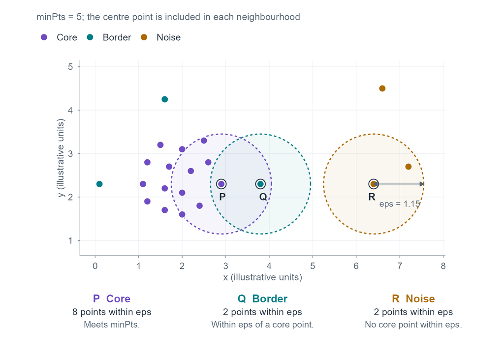

先看邻域，再调整参数

`eps`与`minPts`共同定义局部密度门槛：前者决定查多远，后者决定邻域中至少有多少点。**计数包括被查看的点本身。**

在二维平面上，半径翻倍，邻域圆面积变为4倍。点数门槛不变时，扩大邻域会让更多点有机会达到核心点条件。

| 调整哪一项？ | 固定条件 | 观察什么？ |
| --- | --- | --- |
| 扩大`eps` | 保持`minPts`不变。 | 更多点进入邻域，部分点成为核心点；新簇可能出现，原有簇也可能连接。 |
| 提高`minPts` | 保持`eps`不变。 | 核心点的门槛变高；部分点转为边界或噪声，原簇也可能分裂。 |

[interactive chart not shown]

> **观察重点**：哪些点改变类别，哪些点簇连接或分离？簇号与颜色仅对应当前结果；凹包在后续 AOI 步骤生成。

| 方法或结果 | 本例中回答什么问题？ | 输出 |
| --- | --- | --- |
| KDE | 哪些位置的记录强度较高？ | 连续密度表面；带宽控制平滑尺度。 |
| DBSCAN | 哪些点通过密集邻域连接在一起？ | 点的簇号及噪声标记。 |
| 聚类AOI | 怎样表示已识别点簇的外轮廓？ | 由簇内点生成的面；凹包参数控制轮廓。 |

**KDE 与 DBSCAN：通常选择一种作为主要分析**

两者都属于密度型分析。KDE 呈现连续密度面，DBSCAN 识别点簇与噪声，按研究问题选择即可。

分步运行DBSCAN模板

工作目录设为第5章目录，按以下八步运行。首次绘制底图需要联网；DBSCAN 与凹包均在 UTM 51N 米制坐标下计算，仅将展示副本转回经纬度。

`eps_m`与`min_pts`控制点的聚类，`hull_ratio`控制已识别点簇的外轮廓。修改聚类参数后，从步骤3起顺序重跑；只改变凹包参数时，重跑步骤6、7。

步骤 1：环境与参数

加载本例所需的包，集中设置邻域半径、点数门槛与凹包参数。

**R 代码 · 环境与参数**

```r
# 1. 本例单独运行时加载以下包；已加载的包不必重复执行。
library(dbscan)
library(sf)
library(tidyverse)
library(ggspatial)

# 2. 设置聚类和凹包参数。
eps_m <- 500
min_pts <- 10
hull_ratio <- 0.8

# 3. 注册无密钥的浅灰底图；首次取图需要联网。
esri_light_gray_url <- paste0(
  "https://server.arcgisonline.com/ArcGIS/rest/services/Canvas/",
  "World_Light_Gray_Base/MapServer/tile/${z}/${y}/${x}"
)
rosm::register_tile_source(
  esri_light_gray = rosm::as.tile_source(esri_light_gray_url, extension = "jpg")
)
```

步骤 2：读入、裁取与投影

读取两份 GeoJSON，以区代码裁取闵行，再将点转为米制坐标供聚类计算。

**R 代码 · 读入、裁取与投影**

```r
# 1. 读入区界，只保留区代码、名称与几何。
shanghai_boundary <- st_read("data/shanghai_boundary.geojson", quiet = TRUE) %>%
  select(district_code = "县代码", district_name = "县名") %>%
  st_transform(4326) %>%
  st_make_valid()
minhang_boundary <- shanghai_boundary %>% filter(district_code == 310112)

# 2. 读入咖啡POI，裁取闵行范围；保留原始行序供重复聚类使用。
poi_coffee <- st_read("data/咖啡厅.geojson", quiet = TRUE) %>%
  st_transform(4326)
minhang_cafe_input <- st_filter(
  poi_coffee, minhang_boundary, .predicate = st_intersects
)

# 3. 转为UTM 51N米制坐标，提取DBSCAN的输入矩阵。
cafe_for_clustering <- st_transform(minhang_cafe_input, 32651)
coords <- st_coordinates(cafe_for_clustering)[, c("X", "Y"), drop = FALSE]
```

步骤 3：聚类与点类别

先识别密度簇与核心点，再把簇号和点类别写回原始记录。

**R 代码 · 聚类与点类别**

```r
# 1. 识别密度簇和核心点；minPts包含点本身。
db_res <- dbscan::dbscan(coords, eps = eps_m, minPts = min_pts)
core_point <- dbscan::is.corepoint(coords, eps = eps_m, minPts = min_pts)

# 2. 按原始行序写回结果，再按簇号整理显示顺序。
minhang_cafe <- minhang_cafe_input %>%
  mutate(
    cluster_id = db_res$cluster,
    # 自定义点类别编码；与上面的簇号 cluster_id 分开存放。
    point_type_code = case_when(
      core_point ~ 1L,
      cluster_id > 0 ~ 0L,
      TRUE ~ -1L
    ),
    point_type = case_when(
      point_type_code == 1L ~ "核心点",
      point_type_code == 0L ~ "边界点",
      TRUE ~ "噪声点"
    ),
    cluster_label = if_else(
      cluster_id == 0, "Noise", paste0("Cluster ", cluster_id)
    )
  ) %>%
  arrange(cluster_id)

# 簇号0表示噪声，其余编号用于绘图。
cluster_ids <- sort(unique(db_res$cluster[db_res$cluster > 0]))
```

步骤 4：分类结果汇总

汇总各类点的数量与比例，为后续参数对照提供基准。

下表汇总核心点、边界点与噪声点的数量。比较不同参数时，按空间位置和点成员核对，簇号只表示当前分组。

**R 代码 · 分类结果汇总**

```r
# 按点类别汇总数量与比例。
point_summary <- minhang_cafe %>%
  st_drop_geometry() %>%
  count(point_type, name = "n_points") %>%
  mutate(share = sprintf("%.1f%%", 100 * n_points / sum(n_points)))

knitr::kable(
  point_summary, format = "html",
  caption = paste0("点类别与数量（", length(cluster_ids), "个簇）"),
  col.names = c("点类别", "点数", "比例"), align = c("l", "r", "r")
)
```

点类别与数量（9个簇）

| 点类别 | 点数 | 比例 |
| --- | --- | --- |
| 噪声点 | 381 | 66.7% |
| 核心点 | 138 | 24.2% |
| 边界点 | 52 | 9.1% |

步骤 5：绘制点分类地图

**底图下载失败时怎样继续？**

可暂时删除步骤5和步骤7中的`annotation_map_tile()`图层，保留区界、点与AOI完成分析；无底图时，同时删去`labs()`中`caption`的瓦片来源说明。底图只提供地理参照，不参与DBSCAN或凹包计算。

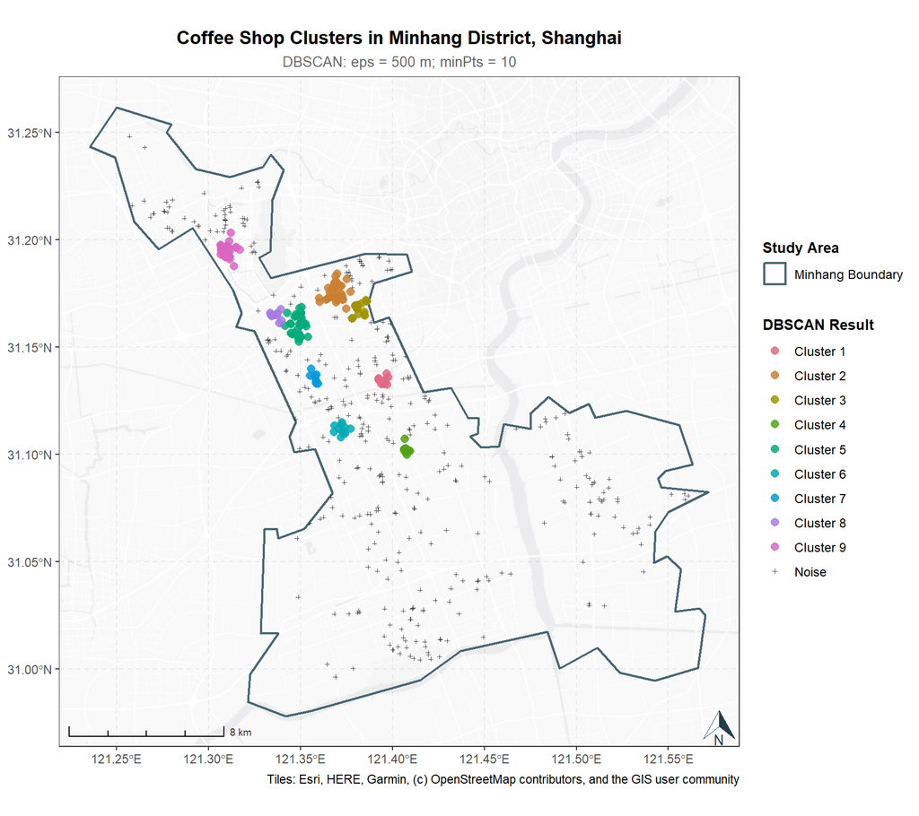

闵行咖啡POI的DBSCAN密度簇；参数见图中副标题，噪声点单独显示。

**R 代码 · 点分类地图**

```r
# 图例映射与点图
# 按簇号设置离散色盘；噪声单独显示。
cluster_cols <- setNames(
  grDevices::hcl.colors(length(cluster_ids), palette = "Dark 3"),
  sprintf("Cluster %s", cluster_ids)
)

# 设定噪声点颜色，并合并为统一的颜色映射表
plot_cols <- c("Noise" = "grey20", cluster_cols)

# 设定形状映射：噪声点为十字，聚类点为实心圆
plot_shapes <- c(
  "Noise" = 3,
  setNames(rep(16, length(cluster_ids)), names(cluster_cols))
)

# 设定大小映射：噪声点较小，聚类点相对更突出
plot_sizes <- c(
  "Noise" = 0.8,
  setNames(rep(2.5, length(cluster_ids)), names(cluster_cols))
)

# 5. 可视化：闵行区咖啡店 DBSCAN 聚类结果
# 使用步骤 1 注册的 Esri 浅灰底图；底图不参与聚类。

ggplot() +
  # 5.1 底图图层
  annotation_map_tile(
    type = "esri_light_gray",
    zoom = 12,
    alpha = 0.40,
    quiet = TRUE
  ) +

  # 5.2 行政边界图层
  geom_sf(
    data = minhang_boundary,
    aes(linetype = "Minhang Boundary"),
    fill = NA,
    colour = "#496672",
    linewidth = 0.8,
    alpha = 0.8
  ) +

  # 5.3 点要素图层
  # 同时映射颜色、形状与大小，以保证图面与图例表达一致
  geom_sf(
    data = minhang_cafe,
    aes(
      color = cluster_label,
      shape = cluster_label,
      size = cluster_label
    ),
    alpha = 0.85
  ) +

  # 5.4 制图要素：比例尺与指北针
  annotation_scale(
    location = "bl",
    width_hint = 0.25,
    style = "ticks",
    text_cex = 0.6,
    text_col = "grey20"
  ) +
  annotation_north_arrow(
    location = "br",
    which_north = "true",
    height = grid::unit(0.8, "cm"),
    width = grid::unit(0.8, "cm"),
    pad_x = grid::unit(0.1, "cm"),
    pad_y = grid::unit(0.1, "cm"),
    style = north_arrow_orienteering(
      fill = c("white", "#253e49"),
      line_col = "#253e49",
      line_width = 0.6,
      text_col = "#253e49",
      text_size = 8
    )
  ) +

  # 5.5 图例与标度设置
  scale_linetype_manual(
    name = "Study Area",
    values = c("Minhang Boundary" = "solid")
  ) +
  scale_color_manual(
    name = "DBSCAN Result",
    values = plot_cols
  ) +
  scale_shape_manual(
    name = "DBSCAN Result",
    values = plot_shapes
  ) +
  scale_size_manual(
    name = "DBSCAN Result",
    values = plot_sizes
  ) +

  # 调整图例顺序，并覆盖边界图例的默认显示样式
  guides(
    linetype = guide_legend(
      override.aes = list(color = "#496672", linewidth = 0.8),
      order = 1
    ),
    color = guide_legend(order = 2),
    shape = guide_legend(order = 2),
    size = guide_legend(order = 2)
  ) +

  # 5.6 版式设置
  theme_bw() +
  theme(
    legend.position = "right",
    legend.title = element_text(size = 10, face = "bold"),
    legend.text = element_text(size = 9),
    plot.title = element_text(face = "bold", hjust = 0.5),
    plot.subtitle = element_text(color = "grey40", hjust = 0.5, size = 10),
    panel.grid.major = element_line(colour = "grey90", linetype = "dashed")
  ) +

  # 5.7 图题与附注
  labs(
    title = "Coffee Shop Clusters in Minhang District, Shanghai",
    subtitle = sprintf("DBSCAN: eps = %s m; minPts = %s", eps_m, min_pts),
    caption = paste(
      "Tiles: Esri, HERE, Garmin, (c) OpenStreetMap contributors,",
      "and the GIS user community"
    )
  )
```

**读图顺序**：先看簇的位置与点数，再看未归簇点的分布；连续核心点怎样连接，可回到上方交互模块查看。500米／10点基准下，571点中有190点归入9个簇，381点为噪声，约占66.7%。已归簇点主要分布在研究区北部与中部，南部和东南部较多点未归簇；这些位置没有达到当前密度门槛。交通枢纽、办公与居住功能可作为后续核查线索。

步骤 6：生成聚类AOI

按簇汇总点，再计算凹包，得到每个簇的外轮廓。该AOI表示**算法选出的点集范围**；识别实际商圈还需经营联系、客流或调查资料。

**R 代码 · 生成聚类 AOI**

```r
# 1. 提取已归簇点，在UTM 51N米制坐标下计算轮廓。
cluster_points_projected <- minhang_cafe %>%
  filter(cluster_id != 0) %>%
  st_transform(32651)

# 2. 按簇合并点，再计算凹包；hull_ratio只控制轮廓形态。
aoi_geometries_projected <- cluster_points_projected %>%
  group_by(cluster_label) %>%
  summarise(geometry = st_union(geometry), .groups = "drop") %>%
  st_concave_hull(ratio = hull_ratio, allow_holes = FALSE)

# 3. 只保留能够成面的簇；共址或共线点集可能只形成点或线。
aoi_polygons_projected <- aoi_geometries_projected %>%
  filter(st_geometry_type(.) %in% c("POLYGON", "MULTIPOLYGON"))

# 米制副本保留供分析，仅将地图显示副本转回经纬度。
# 当前参数无簇时，各对象均返回空sf，不会保留上次结果。
aoi_polygons <- aoi_polygons_projected %>%
  st_transform(4326)
```

每次计算都重新生成AOI。没有可成面的簇时，结果为空，不会沿用上次的面。

步骤 7：绘制聚类AOI地图

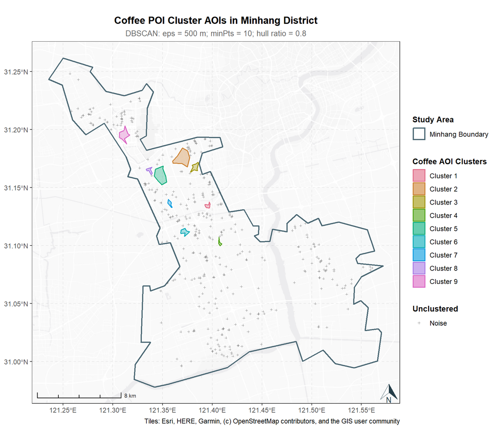

同一DBSCAN结果的聚类AOI；聚类与凹包参数见图中副标题。

**R 代码 · 聚类 AOI 地图**

```r
ggplot() +
  # 7.1 底图图层
  annotation_map_tile(
    type = "esri_light_gray",
    zoom = 12,
    alpha = 0.40,
    quiet = TRUE
  ) +

  # 7.2 行政边界图层
  geom_sf(
    data = minhang_boundary,
    aes(linetype = "Minhang Boundary"),
    fill = NA,
    colour = "#496672",
    linewidth = 0.8,
    alpha = 0.8
  ) +

  # 7.3 聚类AOI多边形图层
  # 使用填充色与边框色同时区分不同聚类簇
  geom_sf(
    data = aoi_polygons,
    aes(
      fill = cluster_label,
      color = cluster_label
    ),
    alpha = 0.35,    # 保持一定透明度，便于识别底图信息
    linewidth = 0.6  # AOI 边界线宽
  ) +

  # 7.4 噪声点图层
  # 将未被聚类识别的点保留在图中，用作空间对照
  geom_sf(
    data = minhang_cafe %>% filter(cluster_id == 0),
    aes(shape = "Noise"),
    color = "grey30",
    size = 0.8,
    alpha = 0.6
  ) +

  # 7.5 制图要素：比例尺与指北针
  annotation_scale(
    location = "bl",
    width_hint = 0.25,
    style = "ticks",
    text_cex = 0.6,
    text_col = "grey20"
  ) +
  annotation_north_arrow(
    location = "br",
    which_north = "true",
    height = grid::unit(0.8, "cm"),
    width = grid::unit(0.8, "cm"),
    pad_x = grid::unit(0.1, "cm"),
    pad_y = grid::unit(0.1, "cm"),
    style = north_arrow_orienteering(
      fill = c("white", "#253e49"),
      line_col = "#253e49",
      line_width = 0.6,
      text_col = "#253e49",
      text_size = 8
    )
  ) +

  # 7.6 图例与标度设置
  scale_linetype_manual(
    name = "Study Area",
    values = c("Minhang Boundary" = "solid")
  ) +
  scale_fill_manual(
    name = "Coffee AOI Clusters",
    values = cluster_cols,
    limits = names(cluster_cols)
  ) +
  scale_color_manual(
    name = "Coffee AOI Clusters",
    values = cluster_cols,
    limits = names(cluster_cols)
  ) +
  scale_shape_manual(
    name = "Unclustered",
  values = c("Noise" = 3),
  limits = "Noise",
  breaks = if (any(minhang_cafe$cluster_id == 0)) "Noise" else character()
  ) +

  # 调整图例顺序，并统一图例显示样式
  guides(
    linetype = guide_legend(
      override.aes = list(color = "#496672", linewidth = 0.8),
      order = 1
    ),
    fill = guide_legend(
      order = 2,
      override.aes = list(alpha = 0.6)
    ),
    color = guide_legend(order = 2),
    shape = guide_legend(order = 3)
  ) +

  # 7.7 版式设置
  theme_bw() +
  theme(
    legend.position = "right",
    legend.title = element_text(size = 10, face = "bold"),
    legend.text = element_text(size = 9),
    plot.title = element_text(face = "bold", hjust = 0.5),
    plot.subtitle = element_text(color = "grey40", hjust = 0.5, size = 10),
    panel.grid.major = element_line(colour = "grey90", linetype = "dashed")
  ) +

  # 7.8 图题与附注
  labs(
    title = "Coffee POI Cluster AOIs in Minhang District",
    subtitle = sprintf("DBSCAN: eps = %s m; minPts = %s; hull ratio = %s",
        eps_m, min_pts, hull_ratio),
    caption = paste(
      "Tiles: Esri, HERE, Garmin, (c) OpenStreetMap contributors,",
      "and the GIS user community"
    )
  )
```

**凸包与凹包怎样选？**

凸包是包住全部输入点的最小凸多边形；凹包允许边界向内凹陷，也应覆盖输入点。本例`hull_ratio = 0.8`控制轮廓形态，取1时对应凸包；它不表示保留80%的点或面积。`allow_holes = FALSE`不保留内部洞，轮廓内的空白仍应结合原始点图检查。

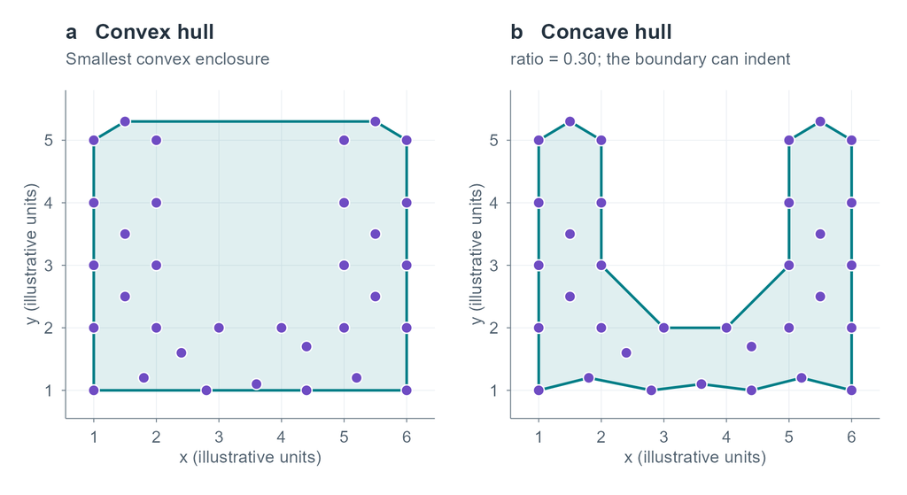

同一组模拟点的凸包与凹包：两者均覆盖全部输入点，凹包允许边界内凹；坐标仅为示意单位。

步骤 8：参数对照：改变半径

固定点数门槛与同一批点，比较 300、500、700 米三种邻域半径。

以下是一组独立的半径对照：固定同一批POI、研究区与米制投影，保持`minPts = 10`，只改变邻域半径。下表由当前点坐标重新计算；最大簇占比的分母为全部区内点。

**R 代码 · 半径参数对照**

```r
# 只改变 eps；固定相同点集、投影与 minPts，便于比较空间尺度。
parameter_comparison <- lapply(c(300, 500, 700), function(candidate_eps_m) {
  candidate_fit <- dbscan::dbscan(coords, eps = candidate_eps_m, minPts = 10)
  point_labels <- candidate_fit$cluster
  # 簇号 0 是噪声；这里只统计已归簇点的簇大小。
  cluster_sizes <- table(point_labels[point_labels > 0])
  tibble::tibble(
    eps_m = candidate_eps_m,
    min_pts = 10L,
    n_clusters = length(cluster_sizes),
    noise_percent = 100 * mean(point_labels == 0),
    largest_percent = 100 * max(c(0, cluster_sizes)) / length(point_labels)
  )
}) %>% dplyr::bind_rows()

parameter_comparison %>%
  dplyr::mutate(
    noise_percent = sprintf("%.2f%%", noise_percent),
    largest_percent = sprintf("%.2f%%", largest_percent)
  ) %>%
  knitr::kable(
    format = "html", align = c("r", "r", "r", "r", "r"),
    col.names = c("eps（米）", "minPts", "簇数", "噪声比例", "最大簇占比")
  )
```

| eps（米） | minPts | 簇数 | 噪声比例 | 最大簇占比 |
| --- | --- | --- | --- | --- |
| 300 | 10 | 6 | 81.26% | 6.13% |
| 500 | 10 | 9 | 66.73% | 7.71% |
| 700 | 10 | 7 | 53.24% | 13.31% |

半径从300米增至700米时，簇数依次为6 → 9 → 7。部分原先未归簇的点达到密度门槛，形成新簇；原有簇也可能连接起来。因此，**簇数不必随半径增大而持续减少**。可回到上方真实POI演示，查看新簇出现、原簇合并及噪声转入簇的位置。

**怎样选参数，而不只看图是否好看？**

先说明希望识别的集聚尺度，再确定候选值。定位精度、设施间距与研究目的都应参与判断；噪声最少或簇数最多，不能单独作为择优标准。

1. **先选点数门槛**：结合数据规模及研究希望识别的局部集聚，设置候选`minPts`。
2. **查看邻居距离**：当`minPts = 10`时，用`dbscan::kNNdistplot(coords, k = 9)`查看第9个其他邻居的距离排序曲线。转折可提示候选半径，实际数据也可能没有清楚的转折。
3. **每次只改变一项**：同时查看点的位置、簇成员与噪声比例，报告哪些结构保留、哪些结构改变。

| 要核查的设置 | 候选与固定条件 | 记录什么？ |
| --- | --- | --- |
| 邻域半径`eps` | 上表已比较300、500、700米；固定`minPts = 10`。 | 簇数、噪声比例、最大簇占比与合并／分裂位置。 |
| 点数门槛`minPts` | 可在演示中比较5、10、15；固定`eps = 500`米。 | 核心点、边界点和噪声怎样变化。 |
| 凹包`ratio` | 固定已识别的簇，再比较0.5、0.8、1。 | AOI面积与轮廓；簇号和噪声比例应保持不变。 |

本例使用直线距离。隔河或被道路屏障分开的点仍可能很近；若问题涉及步行联系，应进一步选择适合的距离定义。边界附近的截点影响可联系专题2的通用反思。

**方法阅读**：[dbscan官方入门](https://michael.hahsler.net/dbscan/articles/dbscan.html)可配合参数对照阅读；[Hahsler等（2019）的R实现论文](https://doi.org/10.18637/jss.v091.i01)解释算法及其实现。[sf文档](https://r-spatial.github.io/sf/reference/geos_unary.html)用于查询凹包形态参数与版本要求。

**选学：把事件发生的时间加入邻域**

同一街口一小时内连续发生的事故，与相隔数月的事故，可以形成不同的研究问题。常见的ST-DBSCAN实现同时设置空间和时间阈值：两个事件只有在空间距离与时间差均满足条件时，才互为邻居，再依据点数判断核心点。例如，空间阈值为300米、时间阈值为30分钟。

空间阈值须与投影坐标同单位，时间阈值须与输入时间同单位；先统一时区，再将时间换算成明确的秒或分钟。阈值约束相邻事件，链式连接后的簇仍可持续更长时间。

Birant与Kut（2007）的原文还讨论了非空间属性等扩展。双阈值软件实现与原算法的全部细节应分别核对。阅读：[原始论文](https://doi.org/10.1016/j.datak.2006.01.013)；[stdbscan官方文档](https://cran.r-project.org/web/packages/stdbscan/stdbscan.pdf)，查看`eps_spatial`、`eps_temporal`与`min_pts`。

**选学：地块邻域与不同密度下的聚类**

DBSCAN的邻域思想也可用于面对象或不同密度的点集。更换对象或算法时，需要重新说明邻域关系与密度判据。

| 方法 | 怎样用于其他研究？ | 阅读 |
| --- | --- | --- |
| GDBSCAN | 将邻域关系与密度判据推广到空间面及属性，可研究地块群；相交、边界间距、属性相似性需按问题选定。 | [Sander等（1998）原文](https://doi.org/10.1023/A:1009745219419)包含二维多边形应用。 |
| HDBSCAN | 在多个密度层级中提取较稳定的簇，可探索商业中心与稀疏外围设施并存的点集，仍需选择参数并检查结果。 | [Campello等（2013）论文](https://doi.org/10.1007/978-3-642-37456-2_14)；[R文档](https://michael.hahsler.net/dbscan/reference/hdbscan.html)。 |
| OPTICS | 通过可达距离排序展示密度结构，可检查主商业带与支路小簇；输出簇号还需选择提取规则。 | [Ankerst等（1999）论文](https://doi.org/10.1145/304182.304187)；[R文档](https://michael.hahsler.net/dbscan/reference/optics.html)。 |

地块的几何邻近与社会经济属性相似回答不同问题。按属性得到同类地块后，若研究要求连续片区，还须检查连通性；将地块换成中心点会改变邻域含义。

**本例学习要点**

- 得到点类别汇总、聚类点图、聚类 AOI 图与半径对照表。
- 能解释核心点、边界点与噪声，以及聚类参数和凹包参数各自改变什么。

作业：小组实践与展示

选择一份空间点数据，自定研究问题与分析范围，使用本章学过的方法完成一份本地 `R Markdown` 报告。练习重点是**参数敏感性分析**：关键参数改变后，主要空间模式是否仍然成立？

练习要求

1. 说明数据来源、记录含义、时间与研究范围，完成坐标系检查及必要的数据清理。
2. 自主选择分析方法，说明主参数的含义与取值理由；另设一组对照参数，每次只改变一项，其余条件保持一致。
3. Knit生成可在浏览器中直接打开的本地HTML，用图表展示主要发现及参数对照结果，分析代码与文字由小组自行组织。

**完成前检查**

- **数据**：写清记录单位、研究范围、CRS和清理后的有效记录数。
- **对照**：列出主参数与对照参数，确认只改变了一项设定。
- **图形**：使用相同的地图范围和可比的图例，避免把显示差异当成分析差异。
- **结果**：报告与方法对应的数量变化，如AOI面积、簇数、噪声比例、Moran’s I或显著LISA单元数。
- **解释**：分别指出稳定模式、敏感模式及解释边界，并联系参数的尺度或邻域含义。
- **输出**：关闭R会话后用浏览器打开本地HTML，确认图表和必要交互可用。

参数可以怎样调整？

根据所选方法，任选一项开展试验。每次记录参数值，并用相同的地图范围和可比的图例呈现结果。

| 所选方法 | 可调整的一项设定 | 观察重点 |
| --- | --- | --- |
| 六边形聚合 | 网格面积或网格起点 | 哪些点重新归格，高低值分布是否改变 |
| KDE／AOI | 带宽或 AOI 提取阈值 | 高值区的位置、平滑程度或边界范围 |
| DBSCAN | `eps` 或 `minPts` | 簇的连接与分离、归簇点与噪声点的变化 |
| Moran’s I／LISA | 邻接规则或空间权重设定 | 全局统计量及局部聚类位置是否稳定 |

**改动后需要重算什么？**

| 改动 | 需要重算的结果 |
| --- | --- |
| KDE带宽 | 密度面、AOI，以及使用新AOI分组的距离与检验 |
| P95等AOI阈值 | AOI，以及使用新AOI分组的距离与检验；原密度面可以保留 |
| DBSCAN的`eps`或`minPts` | 点类别、簇号及聚类AOI |
| 仅改变`hull_ratio` | AOI轮廓与面积；簇号和噪声结果保持不变 |
| 邻接规则或空间权重 | Moran’s I、LISA及相应检验 |

备选数据与选题提示

**优先选题**使用[课程数据页](https://dawn-ecnu.github.io/data/)中的商业POI、公共交通设施及本章已有数据，可将主要时间用于参数对照。**进阶选题**使用下列外部平台数据，需要额外完成下载、筛选或表格关联，适合希望继续练习数据清理的小组。研究范围、方法与参数由小组确定。

| 数据入口 | 可研究的问题 | 数据处理提示 |
| --- | --- | --- |
| **优先** · [上海 POI 与交通设施](https://dawn-ecnu.github.io/data/) | 某类设施集中在哪里？活动点与交通设施的距离有什么特点？ | 可沿用本章数据；直线距离用于描述设施邻近性 |
| **进阶** · [纽约交通碰撞](https://data.cityofnewyork.us/Public-Safety/Motor-Vehicle-Collisions-Crashes/h9gi-nx95/about_data) | 行人或自行车碰撞集中在哪些位置？集聚范围是否随参数改变？ | 有事件 ID、日期、坐标及伤亡字段；按时期与事件类型筛选，检查缺失坐标 |
| **进阶** · [纽约市现行树木点：ForMS](https://data.cityofnewyork.us/Environment/Forestry-Tree-Points/hn5i-inap) | 树木数量、胸径或状况在空间上有什么差异？ | 持续更新的管理记录；对象与筛选口径见下方“下载与预读” |
| **进阶** · [英国警方犯罪数据](https://data.police.uk/data/) | 某类犯罪记录集中在哪里？带宽或邻域半径变化后，哪些区域保持稳定？ | 可按月份与警区下载 CSV；发布坐标为匿名近似位置，[定位说明见官方文档](https://data.police.uk/about/) |
| **进阶** · [USGS 地震目录](https://earthquake.usgs.gov/earthquakes/search/) | 震中记录集中在哪里？KDE带宽或DBSCAN半径改变后，集聚范围如何变化？ | 固定区域、时期与震级范围；二维分析使用震中位置，深度不计入平面距离 |
| **进阶** · [Citi Bike 骑行与站点](https://citibikenyc.com/system-data) | 出发事件集中在哪里？站点使用强度有什么空间差异？ | 区分站点与骑行事件；月度文件较大，可限定日期。按[数据使用协议](https://citibikenyc.com/data-sharing-policy)从官方获取数据 |

**纽约交通碰撞 · 下载步骤**

1. 打开[官方数据页](https://data.cityofnewyork.us/Public-Safety/Motor-Vehicle-Collisions-Crashes/h9gi-nx95/about_data)，核对数据集名称与 **Data Last Updated**。每行代表一次交通碰撞。
2. 全量数据较大，可先在 **Data** 页按研究范围和时段筛选。
3. 点击 **Export**，在 **Download file** 中选择 **CSV**，核对导出范围与行数，再点击 **Download** 保存文件。

**预读提示：网页预览与 API 返回量**

网页一次显示多少行，与导出多少行是两件事。直接读取 API 地址也可能只取得一页，需要按[接口文档](https://dev.socrata.com/docs/queries/limit.html)明确范围并分页读取。使用网页导出时，核对筛选条件与导出行数即可。

清理时按 `collision_id` 核对重复导入；相同坐标的不同碰撞仍保留为不同事件。

[figure not shown]

交通碰撞官方数据页：核对数据名称与数据更新时间。

[figure not shown]

CSV 导出窗口：检查格式与导出范围后下载。

官网截图采集于 2026-10-21。

**ForMS 树木与种植位 · 下载与预读**

官方渠道：[Forestry Tree Points（树木点表）](https://data.cityofnewyork.us/Environment/Forestry-Tree-Points/hn5i-inap/about_data)；[Forestry Planting Spaces（种植位表）](https://data.cityofnewyork.us/Environment/Forestry-Planting-Spaces/82zj-84is/about_data)。若限定研究行道树，需要两表共同判断。

1. 分别打开所需数据页，核对名称和 **Data Last Updated**，按研究范围筛选。
2. 点击 **Export**，将 **Export format** 改为 **GeoJSON**，核对导出范围后下载。可分别保存为 `tree_points.geojson`、`planting_spaces.geojson`。也可使用官方[树木点 GeoJSON 导出](https://data.cityofnewyork.us/api/geospatial/hn5i-inap?method=export&format=GeoJSON)和[种植位 GeoJSON 导出](https://data.cityofnewyork.us/api/geospatial/82zj-84is?method=export&format=GeoJSON)链接获取全表。
3. 沿用第四章的 `sf::st_read()` 读取本地文件，先查看字段、记录数和坐标系，再确定筛选条件。

**预读提示：树木对象与种植位置**

ForMS 是持续更新的管理记录，同一位置可能先后对应退役树木和补种树木。两表记录的对象不同：

| 数据表 | 先核对什么？ |
| --- | --- |
| 树木点表 | `tpstructure` 表示结构，如 `Full`、`Stump`、`Retired`；`tpcondition` 表示状况。结构为 `Full` 的记录也可能标为 `Dead` |
| 种植位表 | `pssite` 区分街道、公园等位置；空种植位不能计作树木。限定行道树时核对 `pssite == "Street"` |

树木表的 `plantingspaceglobalid` 对应种植位表的 `globalid`。关联方法沿用第二章；两表都读为 `sf` 时，先用 `st_drop_geometry()` 取出种植位属性，保留树木点的几何。记录下载日期及结构、状况的筛选口径。

[figure not shown]

树木点表：Forestry Tree Points。

[figure not shown]

导出时选择 GeoJSON，保留点几何。

[figure not shown]

种植位表：Forestry Planting Spaces，按相同步骤导出。

官网截图采集于 2026-10-21。

**英国警方犯罪数据 · 下载步骤**

图示以伦敦 2026 年 3 至 4 月的犯罪数据演示下载流程；月份与警区可根据选题调整。

**预读提示：匿名位置与空案件编号**

公开坐标经过[匿名化处理](https://data.police.uk/about/#location-anonymisation)，多个事件可映射到同一参考点。`Crime ID` 也可能为空，例如反社会行为记录；空编号不表示同一事件，不能直接按坐标或空编号去重。合并月份时保留来源文件名，并核对有效事件编号。

[figure not shown]

英国警方犯罪数据下载示意图。图片由课程教师提供。

**Citi Bike 站点 · 下载步骤**

1. 打开 [Citi Bike System Data](https://citibikenyc.com/system-data)，找到 **Real-Time Data**，点击 **Get the GBFS feed here**。
2. 在 GBFS 目录的 `en` 下找到 `station_information`，打开对应的 `url`。也可直接访问[官方站点 JSON](https://gbfs.lyft.com/gbfs/2.3/bkn/en/station_information.json)。
3. 使用浏览器的“另存为”保存 `.json` 文件，文件名可包含下载日期。站点记录位于 `data → stations`，坐标字段为 `lon`、`lat`；`station_id` 保留为字符型。

**预读提示：GBFS 的嵌套 JSON**

GBFS 是共享出行实时数据的发布规范。`station_information` 的普通 JSON 按层级组织，站点表位于 `data → stations`，一行对应一个站点，可用于研究站点分布。研究骑行使用强度时，需要使用官网的月度 **Trip Histories**，按站点汇总出发或到达次数，同站的多次骑行应保留。

预读时可使用 `jsonlite::fromJSON()`，需先安装 `jsonlite` 包。若将读取结果命名为 `station_json`，取出 `station_json$data$stations` 后，再沿用第四章的经纬度转 `sf` 流程。

`station_status` 提供某一时刻的可用车辆、车桩等状态，可按 `station_id` 连接；单次状态不能表示一段时期的骑行次数。GBFS 还含纽约市外站点，分析时按研究区边界裁取。

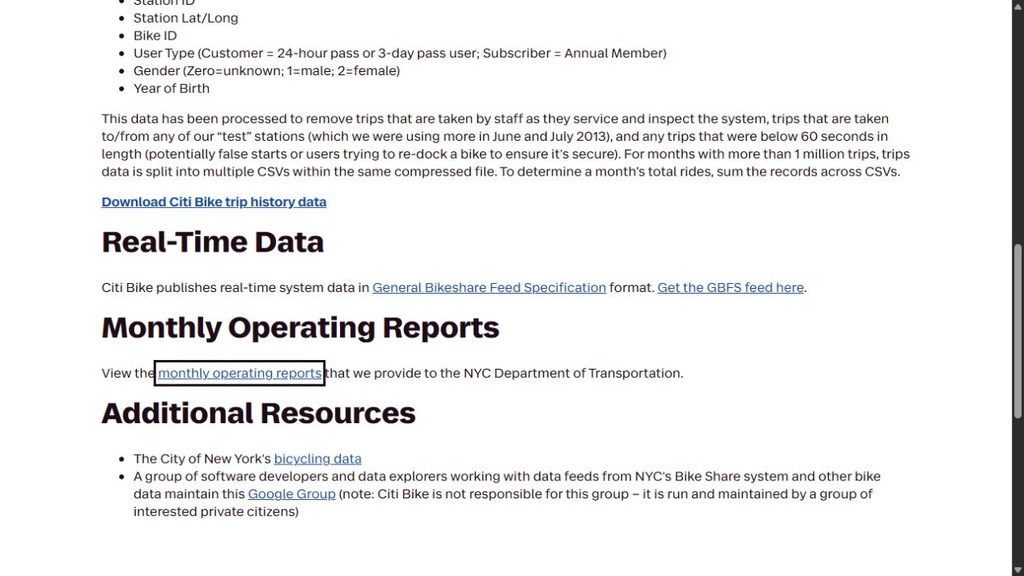

站点入口位于 Real-Time Data。

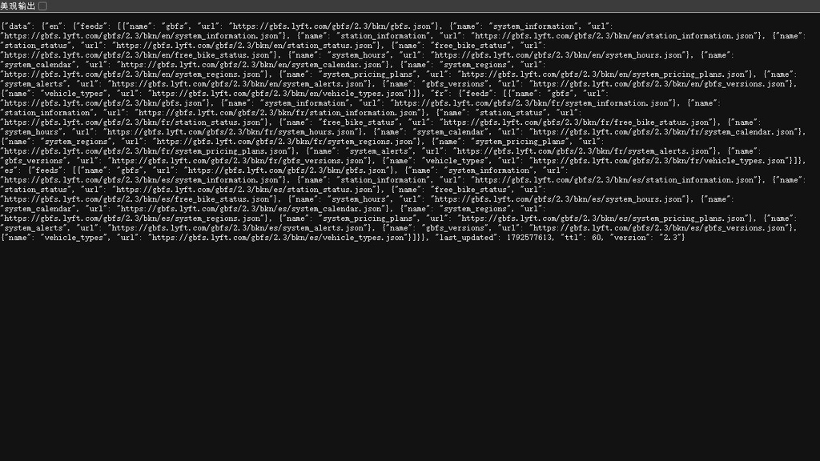

GBFS 目录：查找 station_information 对应的地址。

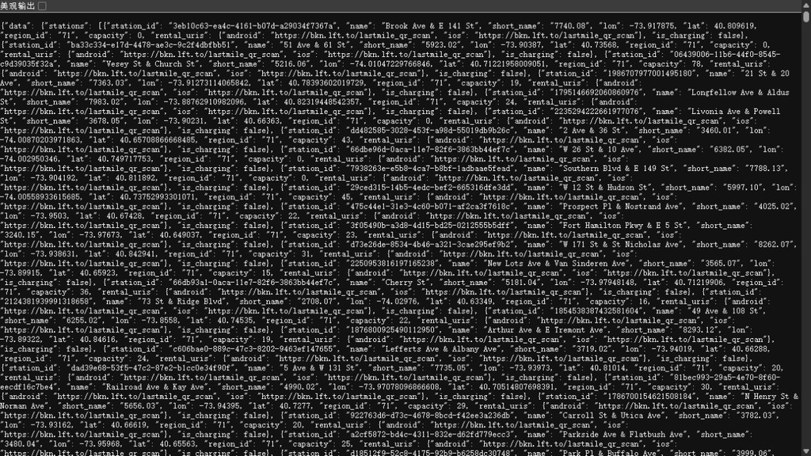

站点 JSON：data → stations 保存站点记录。

官网截图采集于 2026-10-21。

测评：知识点自测

已检查 0 / 6 题

01基础 · 点记录与坐标一份签到 sf 数据已正确声明为 EPSG:4326，每行代表一次签到。两行坐标相同，但时间不同。准备计算米制距离，哪种处理合适？ A．按坐标去重，再用 `st_set_crs(32651)` 把坐标改成米。 B．保留两次签到，转换到当地合适的米制投影后计算距离。 C．保留两次签到，将经纬度差直接当作米制距离。 D．点的几何维度为0，不能计算点间距离。

02基础至中等 · 空间聚合同一批点分别汇总到两套正六边形。两套网格面积、方向相同，只平移网格起点；部分高值格的位置随后改变。哪种解释合适？ A．属于尺度效应，因为每格纳入的点数发生了变化。 B．原始点的位置发生了变化，应先修复定位错误。 C．属于分区效应，需比较重新归格后哪些模式保持稳定。 D．高值格变少的方案更准确，应采用该方案。

03中等 · 距离与解释某区AOI内记录到地铁POI的平均距离比非AOI短107米。以固定AOI为条件、按账号聚类的均值差检验经Holm校正后p < 0.001。哪项解释合适？ A．均值差显著，说明AOI内每条记录都比非AOI记录更靠近地铁。 B．p < 0.001来自P95密度阈值，说明AOI是统计显著热点。 C．当前样本和固定AOI下的均值差有统计证据；实际便利与空间公平还需其他资料。 D．距离短107米足以判定实际更便利、供给更公平，无需补充资料。

04较难 · 全局与局部关联某研究的全局 Moran’s I 显著为正。一个格在 Moran 散点图的HH象限，但其局部检验经多重比较调整后未达到0.05门槛。哪项解释合适？ A．全局检验已经显著，该格应直接标为显著HH。 B．该格未显著，说明全局正向关联的结果有误。 C．该格价格受到邻格价格的因果影响。 D．整体存在正向空间关联，该格的HH方向尚未通过局部显著性判断。

05较难 · KDE与AOI研究将2023—2025年记录合并，以每区单一KDE的区内密度P95提取AOI。下列哪项理解准确？ A．AOI必须恰好包含95%的原始点。 B．AOI由区内密度达到P95的范围构成，点的覆盖比例需另行统计。 C．AOI内的密度均已通过显著性水平0.05的检验。 D．将KDE带宽加倍后，只需更换色盘，原AOI仍可沿用。

06中等 · 聚类与代码points_m 已转换到当地合适的米制投影。运行 `dbscan::dbscan(sf::st_coordinates(points_m), eps = 300, minPts = 5)`。点P的300米邻域内连同自身共有4个点，但P位于一个核心点的300米邻域内。P应怎样分类？ A．边界点。 B．核心点，因为还应把点P自身再计入一次，达到5点。 C．噪声点，因为它自身邻域不足5点。 D．无法判断，因为代码没有指定聚类个数。

**© 华东师范大学 社会发展学院 人口研究所** | [**DAWN 研究组**](https://dawn-ecnu.github.io) | yzliu@soci.ecnu.edu.cn

课程负责人：刘贇喆 本章作者：刘贇喆 | 敖漪宇

最后更新：2026年11月13日 构建环境：R version 4.6.1 (2026-06-24 ucrt)

[CC BY-NC-SA 4.0](https://creativecommons.org/licenses/by-nc-sa/4.0/deed.zh) 回到顶部